# Reading the body of the book: what a local scanner can and cannot catch

Version 2.2 — 2026-07-24 — office 4090 box + rented A100 sessions. v2.1 added the unquantized-35B verification; v2.2 adds the production pipeline (§7), the 120B negative result, the 1929 marker list, stage 3, and the OOS validation context (see PIPELINE.md + PREREGISTRATION_OOS.md).  
Data: D:\UZHechist Dropbox\Joachim Voth\claudecode\ranke-contamination-audit\experiments\content-dating\; code + manifests: github.com/huggingbeard/ranke-edition-dating, experiments/content-dating/. All parameters PROVISIONAL pending PI review.

## 1. What we are establishing

**Question:** the production pipeline dates books from front matter only; how much post-1929 *body* content can a local model catch, at what false-alarm cost, with what hardware?

**Answers.** (1) On the hardest realistic positives — 1930s–40s ordinary authored books — no single model or ensemble reaches the recall-0.95 target at ≤10% false positives. (2) The practical frontier: a **gpt-oss-20b + Qwen2.5-14B passage-agreement ensemble** reaches recall 0.90 (contaminants) / 0.80 (1930s books) at 9% FP entirely on the 4090; the **Qwen3.6-35B-A3B** (3-bit, llama.cpp) is the strongest single judge — 0.92/0.92 at 18% FP, 0.89/0.78 at 6.5% — but runs 25× slower than gpt-oss on a 24 GB card. (3) The residual misses are books whose body text is genuinely undatable (archaic genres); their dates live in front matter, so body-reading *complements* the existing dater rather than replacing it.

## 2. The data

| Set | n | What it is | Role |
| --- | --- | --- | --- |
| Certified clean negatives | 918 | pre-1929 books, five metadata screens + two-model body read found nothing | false-positive side |
| C — contam_modern | 238 | gold-audited modern-content contaminants in our own corpus | recall headline |
| C — reprint floor | 80 | modern printings of old works (old body text) | should-not-flag diagnostic |
| C — got-throughs | 3 | contaminants the production pipeline missed | hardest cases |
| **B — 1930–46 ordinary books** | 600 | near-boundary authored books (poetry, fiction, local history, textbooks); deepseek title screen + strict both-model modern-original certification (631/899 pass) | **hardest realistic stratum** (PI-requested) |
| A — post-1947 (diagnostic) | 1000 | PD post-1947 ≈ gov docs ("a gov doc classifier by another name") | easy-mode contrast only |

## 3. Method, verbatim

Up to 16 random + 16 grep-directed passages per book at lengths {250, 500, 1000, 2000} chars; every passage judged by every model with this exact prompt (temperature 0, each model's own chat template):

Read this passage from a scanned book and judge: was its text WRITTEN before 1929, or after 1929? Old, foreign-language, poetic, or historical writing is BEFORE. Modern prose, a post-1929 event/person/technology, or a modern perspective is AFTER. Ignore OCR noise. Passage:\n"""{p}"""\nAnswer with only one word: BEFORE or AFTER.

Book flagged when ≥k of the first N passage verdicts say AFTER. Ensembles combine models at the passage level (passage counts as AFTER when ≥m member models agree) or at the book level (all members must flag).

## 4. Results

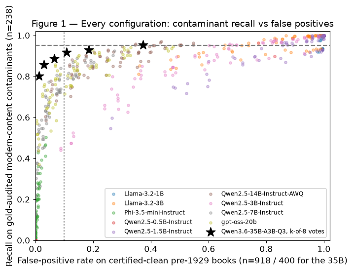

Figure 1: every model × configuration as a point; x = share of clean books wrongly flagged, y = share of known contaminants caught. Black stars: the Qwen3.6-35B at vote thresholds k=1..6 of 8 — a strictly better trade-off curve than every smaller model. Nothing reaches the 0.95 dashed line inside FP ≤ 10%.

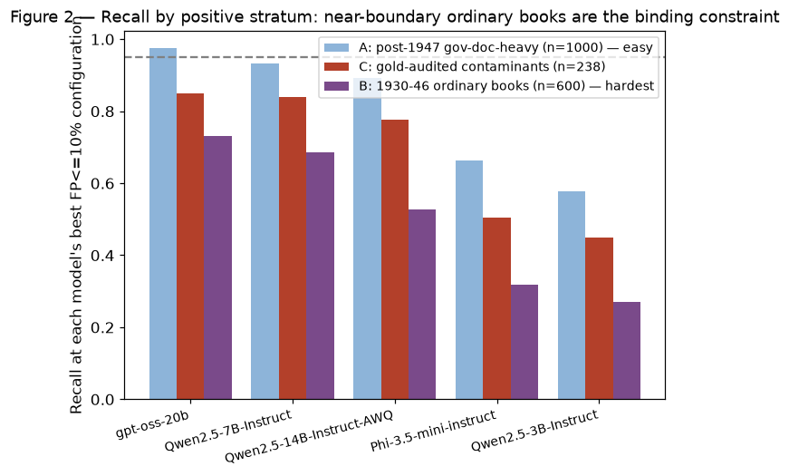

### The frontier in numbers

| scanner | config | recall C (238) | recall B (600) | FP (918) | 4090 GPU-days / 2M books |
| --- | --- | --- | --- | --- | --- |
| gpt-oss-20b (best single, vLLM) | 8×2000 random, 2-of-8 | 0.849 | 0.732 | 6.8% | 5.3 |
| ensemble gptoss+q14b+phi (2of3 passage vote) | 8×2000 grep, k=1 | 0.895 | 0.803 | 9.6% | 25.61 |
| ensemble gptoss+q14b (2of2 passage vote) | 8×2000 grep, k=1 | 0.895 | 0.803 | 9.2% | 20.86 |
| ensemble gptoss+q14b (2of2 passage vote) | 8×2000 random, k=1 | 0.887 | 0.795 | 9.2% | 20.86 |
| Qwen3.6-35B-A3B-Q3, k=3 of 8* | 8×2000 random | 0.916 | 0.855 | 10.8% | ≈53 (llama.cpp, this box) |
| Qwen3.6-35B-A3B-Q3, k=4 of 8* | 8×2000 random | 0.887 | 0.782 | 6.5% | ≈53 |
| **35B (k=2) × gpt-oss (k=1), book-level agreement*** | 8×2000 random | **0.891** | **0.828** | **5.8%** | ≈58 |
| **Qwen3.6-35B-A3B UNQUANTIZED (A100 verification), k=3 of 8** | 8×2000 random | **0.887** | **0.868** | **8.6%** | ≈$180/sweep rented (121 A100-h @ $1.49) |
| — same model, k=4 of 8 (precision mode) | 8×2000 random | 0.866 | 0.777 | 3.8% | ≈$180/sweep |

A100 rows: full frontier slice (918 negatives / 238 contaminants / 600 stratum-B), unquantized BF16 on a rented A100-SXM4-80GB via vLLM (36.8 passages/s over HTTPS; verification cost $0.74). Apples-to-apples on identical books, the local 3-bit GGUF tracks the unquantized model within ~1–3 points on every metric — the quantization is not what limits the 35B; the 24 GB card's runtime is.

* 35B rows from a seeded subsample (238 contaminants / 400 stratum-B / 400 negatives; ±3–5 pp), single config, llama.cpp runtime. All other rows: full sets on vLLM.

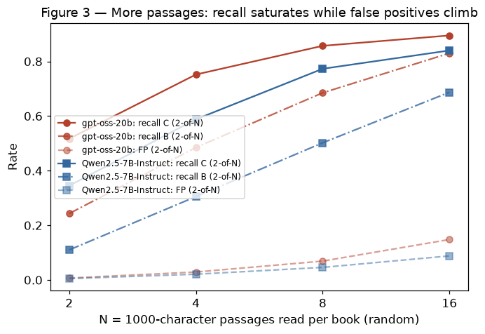

## 5. Why nothing reaches 0.95 — the misses, verbatim

**1947 — devotional poetry, copyright 1947 L. A. Nichols**. Sampled body text:  
*“thy shrine; How sweetly dost thou show thy face; When thou dost own me thine; O Father, let me praise thy name In great humility; Although my frame is only dust, I want to worship thee.”*

**1940 — county local history, copyright 1940, quoting an 1811 newspaper**. Sampled body text:  
*“innati Gazette remarked: The steamboat New Orleans came to anchor before this port on Monday last. This is a large and handsome vessel, burthen 350 tons, intended for the trade of the Mississippi”*

**1947 — GPO taxonomy monograph, printed 1947**. Sampled body text:  
*“manuscript as Oligometra concinna. Upon reviewing the subject more carefully I found that this was at best only an average difference and that no definite line between O. pulchella and O. coneinna could be drawn”*

Hand-checked misses are genuine post-1929 editions (labels certain) whose sampled body carries no date signal: hymns, archaic verse, timeless monographs, antiquarian histories quoting old sources. Every checked miss has its date in *front matter*, which the production dater already reads. The irreducible class = archaic content + wrong-old metadata + no imprint — exactly the got-throughs (best configs catch 0–1 of 3).

## 6. Hardware and cost findings

| model | passages/s (measured) | unparseable |
| --- | --- | --- |
| Qwen/Qwen2.5-0.5B-Instruct | 577.2 | 31 |
| unsloth/Llama-3.2-1B-Instruct | 455.9 | 522 |
| Qwen/Qwen2.5-1.5B-Instruct | 325.3 | 0 |
| unsloth/Llama-3.2-3B-Instruct | 158.3 | 0 |
| Qwen/Qwen2.5-3B-Instruct | 157.7 | 2 |
| microsoft/Phi-3.5-mini-instruct | 101.3 | 0 |
| openai/gpt-oss-20b | 80.8 | 44 |
| Qwen/Qwen2.5-7B-Instruct | 74.7 | 0 |
| Qwen36-35B-A3B-BF16-A100 | 36.6 | 4 |
| Qwen/Qwen2.5-14B-Instruct-AWQ | 31.8 | 0 |
| gptoss-120b-A100 | 4.5 | 22113 |
| Qwen36-35B-A3B-Q3-llamacpp | 1.5 | 17 |

## 7. The production pipeline and its price (added v2.2)

The validated three-stage architecture (authoritative spec: `PIPELINE.md`): **Stage 1** paperwork rule (catalogue year + Guohui's Qwen3-14B doc-year + imprint regex; free, catches ~100% of honest-metadata contamination; flagged reprints routed to the gpt-oss editorial pass — modern apparatus out, clean re-sets rescued) → **Stage 2** reader team on survivors (35B ≥2/8 OR gpt-oss-20b ≥3/8 on 8×2000-char random passages; OOS-validated rescue 0.875 of wrong-metadata contamination at 13.2% clean loss) → **Stage 3** exhaustive word-boundary grep (markers_1945 + 447 null-corpus-validated 1929 terms + year-in-context sieve) with quote-the-proving-phrase adjudication of hit contexts (+30–40% of the readers' leftovers on honest-body books, ~0.5% extra loss).

| Item (2M books, A100-SXM @ $1.49/h, measured throughputs) | A100-h | $ |
| --- | --- | --- |
| Stage 1 + grep scans (CPU) | — | ~5 |
| 35B reader (14.9M passages @ 37/s) | ~112 | ~170 |
| gpt-oss-20b reader (@ ~100/s) | ~41 | ~60 |
| Reprint pass + stage-3 adjudication | ~8 | ~15 |
| **Total (conservative)** / realistic offline-batched | **~160** / ~100 | **~$250** / ~$150 |

Wall-clock shards by book: 1 pod ≈ a week, 4 pods ≈ 2 days, 8 pods ≈ 1 day.

## 8. Caveats (all parameters provisional)

- Llama-3.2-1B's "perfect recall" is degenerate (answers AFTER to ~everything, 99.9% FP) — recall without an FP bound is meaningless.
- Certifier asymmetry: all 81 negative-review flags were Llama-70B-only (deepseek 0); spot-checks read as over-caution (review_queue_negatives.csv).
- 35B numbers: subsample, one config, different runtime (llama.cpp); confirm on rented hardware before production use.
- Single prompt (untuned), single corpus family; passages avoid the first/last 3–5% of each book by design.